# Risk Factor Analysis

## Outcome Variable

**Outcome Variable:** ever_sstunted

## Predictor Variables

**Intervention Variable:** mhtcm

**Adjustment Set:**

- arm
- W_mage
- meducyrs
- feducyrs
- hhwealth_quart
- delta_W_mage
- delta_meducyrs
- delta_feducyrs
- delta_hhwealth_quart

## Stratifying Variables

The analysis was stratified on these variable(s):

- agecat
- studyid
- country

## Data Summary

| agecat | studyid | country | mhtcm | ever_sstunted | n_cell | n |
| --- | --- | --- | --- | --- | --- | --- |
| 0-24 months | ki0047075b-MAL-ED | BANGLADESH | >=155 cm | 0 | 23 | 254 |
| 0-24 months | ki0047075b-MAL-ED | BANGLADESH | >=155 cm | 1 | 2 | 254 |
| 0-24 months | ki0047075b-MAL-ED | BANGLADESH | <151 cm | 0 | 114 | 254 |
| 0-24 months | ki0047075b-MAL-ED | BANGLADESH | <151 cm | 1 | 49 | 254 |
| 0-24 months | ki0047075b-MAL-ED | BANGLADESH | [151-155) cm | 0 | 62 | 254 |
| 0-24 months | ki0047075b-MAL-ED | BANGLADESH | [151-155) cm | 1 | 4 | 254 |
| 0-24 months | ki0047075b-MAL-ED | BRAZIL | >=155 cm | 0 | 123 | 222 |
| 0-24 months | ki0047075b-MAL-ED | BRAZIL | >=155 cm | 1 | 7 | 222 |
| 0-24 months | ki0047075b-MAL-ED | BRAZIL | <151 cm | 0 | 47 | 222 |
| 0-24 months | ki0047075b-MAL-ED | BRAZIL | <151 cm | 1 | 6 | 222 |
| 0-24 months | ki0047075b-MAL-ED | BRAZIL | [151-155) cm | 0 | 34 | 222 |
| 0-24 months | ki0047075b-MAL-ED | BRAZIL | [151-155) cm | 1 | 5 | 222 |
| 0-24 months | ki0047075b-MAL-ED | INDIA | >=155 cm | 0 | 46 | 242 |
| 0-24 months | ki0047075b-MAL-ED | INDIA | >=155 cm | 1 | 9 | 242 |
| 0-24 months | ki0047075b-MAL-ED | INDIA | <151 cm | 0 | 81 | 242 |
| 0-24 months | ki0047075b-MAL-ED | INDIA | <151 cm | 1 | 34 | 242 |
| 0-24 months | ki0047075b-MAL-ED | INDIA | [151-155) cm | 0 | 60 | 242 |
| 0-24 months | ki0047075b-MAL-ED | INDIA | [151-155) cm | 1 | 12 | 242 |
| 0-24 months | ki0047075b-MAL-ED | NEPAL | >=155 cm | 0 | 41 | 238 |
| 0-24 months | ki0047075b-MAL-ED | NEPAL | >=155 cm | 1 | 0 | 238 |
| 0-24 months | ki0047075b-MAL-ED | NEPAL | <151 cm | 0 | 117 | 238 |
| 0-24 months | ki0047075b-MAL-ED | NEPAL | <151 cm | 1 | 16 | 238 |
| 0-24 months | ki0047075b-MAL-ED | NEPAL | [151-155) cm | 0 | 59 | 238 |
| 0-24 months | ki0047075b-MAL-ED | NEPAL | [151-155) cm | 1 | 5 | 238 |
| 0-24 months | ki0047075b-MAL-ED | PERU | >=155 cm | 0 | 49 | 290 |
| 0-24 months | ki0047075b-MAL-ED | PERU | >=155 cm | 1 | 11 | 290 |
| 0-24 months | ki0047075b-MAL-ED | PERU | <151 cm | 0 | 124 | 290 |
| 0-24 months | ki0047075b-MAL-ED | PERU | <151 cm | 1 | 45 | 290 |
| 0-24 months | ki0047075b-MAL-ED | PERU | [151-155) cm | 0 | 54 | 290 |
| 0-24 months | ki0047075b-MAL-ED | PERU | [151-155) cm | 1 | 7 | 290 |

[output cut: 240 more lines]

The following strata were considered:

- agecat: 0-24 months, studyid: ki0047075b-MAL-ED, country: BANGLADESH
- agecat: 0-24 months, studyid: ki0047075b-MAL-ED, country: BRAZIL
- agecat: 0-24 months, studyid: ki0047075b-MAL-ED, country: INDIA
- agecat: 0-24 months, studyid: ki0047075b-MAL-ED, country: NEPAL
- agecat: 0-24 months, studyid: ki0047075b-MAL-ED, country: PERU
- agecat: 0-24 months, studyid: ki0047075b-MAL-ED, country: SOUTH AFRICA
- agecat: 0-24 months, studyid: ki0047075b-MAL-ED, country: TANZANIA, UNITED REPUBLIC OF
- agecat: 0-24 months, studyid: ki1000304b-SAS-CompFeed, country: INDIA
- agecat: 0-24 months, studyid: ki1000304b-SAS-FoodSuppl, country: INDIA
- agecat: 0-24 months, studyid: ki1017093-NIH-Birth, country: BANGLADESH
- agecat: 0-24 months, studyid: ki1017093b-PROVIDE, country: BANGLADESH
- agecat: 0-24 months, studyid: ki1017093c-NIH-Crypto, country: BANGLADESH
- agecat: 0-24 months, studyid: ki1066203-TanzaniaChild2, country: TANZANIA, UNITED REPUBLIC OF
- agecat: 0-24 months, studyid: ki1101329-Keneba, country: GAMBIA
- agecat: 0-24 months, studyid: ki1112895-Guatemala BSC, country: GUATEMALA
- agecat: 0-24 months, studyid: ki1112895-iLiNS-Zinc, country: BURKINA FASO
- agecat: 0-24 months, studyid: ki1119695-PROBIT, country: BELARUS
- agecat: 0-24 months, studyid: ki1126311-ZVITAMBO, country: ZIMBABWE
- agecat: 0-24 months, studyid: ki1135781-COHORTS, country: GUATEMALA
- agecat: 0-24 months, studyid: ki1135781-COHORTS, country: INDIA
- agecat: 0-24 months, studyid: ki1135781-COHORTS, country: PHILIPPINES
- agecat: 0-24 months, studyid: ki1148112-LCNI-5, country: MALAWI
- agecat: 0-24 months, studyid: kiGH5241-JiVitA-3, country: BANGLADESH
- agecat: 0-6 months, studyid: ki0047075b-MAL-ED, country: BANGLADESH
- agecat: 0-6 months, studyid: ki0047075b-MAL-ED, country: BRAZIL
- agecat: 0-6 months, studyid: ki0047075b-MAL-ED, country: INDIA
- agecat: 0-6 months, studyid: ki0047075b-MAL-ED, country: NEPAL
- agecat: 0-6 months, studyid: ki0047075b-MAL-ED, country: PERU
- agecat: 0-6 months, studyid: ki0047075b-MAL-ED, country: SOUTH AFRICA
- agecat: 0-6 months, studyid: ki0047075b-MAL-ED, country: TANZANIA, UNITED REPUBLIC OF
- agecat: 0-6 months, studyid: ki1000304b-SAS-CompFeed, country: INDIA
- agecat: 0-6 months, studyid: ki1000304b-SAS-FoodSuppl, country: INDIA
- agecat: 0-6 months, studyid: ki1017093-NIH-Birth, country: BANGLADESH
- agecat: 0-6 months, studyid: ki1017093b-PROVIDE, country: BANGLADESH
- agecat: 0-6 months, studyid: ki1017093c-NIH-Crypto, country: BANGLADESH
- agecat: 0-6 months, studyid: ki1066203-TanzaniaChild2, country: TANZANIA, UNITED REPUBLIC OF
- agecat: 0-6 months, studyid: ki1101329-Keneba, country: GAMBIA
- agecat: 0-6 months, studyid: ki1112895-Guatemala BSC, country: GUATEMALA
- agecat: 0-6 months, studyid: ki1119695-PROBIT, country: BELARUS
- agecat: 0-6 months, studyid: ki1126311-ZVITAMBO, country: ZIMBABWE
- agecat: 0-6 months, studyid: ki1135781-COHORTS, country: GUATEMALA
- agecat: 0-6 months, studyid: ki1135781-COHORTS, country: INDIA
- agecat: 0-6 months, studyid: ki1135781-COHORTS, country: PHILIPPINES
- agecat: 0-6 months, studyid: ki1148112-LCNI-5, country: MALAWI
- agecat: 0-6 months, studyid: kiGH5241-JiVitA-3, country: BANGLADESH

### Dropped Strata

Some strata were dropped due to rare outcomes:

- agecat: 0-24 months, studyid: ki0047075b-MAL-ED, country: BANGLADESH
- agecat: 0-24 months, studyid: ki0047075b-MAL-ED, country: NEPAL
- agecat: 0-24 months, studyid: ki1112895-Guatemala BSC, country: GUATEMALA
- agecat: 0-6 months, studyid: ki0047075b-MAL-ED, country: BANGLADESH
- agecat: 0-6 months, studyid: ki0047075b-MAL-ED, country: BRAZIL
- agecat: 0-6 months, studyid: ki0047075b-MAL-ED, country: INDIA
- agecat: 0-6 months, studyid: ki0047075b-MAL-ED, country: NEPAL
- agecat: 0-6 months, studyid: ki0047075b-MAL-ED, country: SOUTH AFRICA
- agecat: 0-6 months, studyid: ki1000304b-SAS-FoodSuppl, country: INDIA
- agecat: 0-6 months, studyid: ki1017093b-PROVIDE, country: BANGLADESH
- agecat: 0-6 months, studyid: ki1112895-Guatemala BSC, country: GUATEMALA

## Methods Detail

We’re interested in the causal parameters $E[Y_a]$ for all values of $a \in \mathcal{A}$. These parameters represent the mean outcome if, possibly contrary to fact, we intervened to set all units to have $A=a$. Under the randomization and positivity assumptions, these are identified by the statistical parameters $\psi_a=E_W[E_{Y|A,W}(Y|A=a,W)]$. In addition, we’re interested in the mean of $Y$, $E[Y]$ under no intervention (the observed mean). We will estimate these parameters by using SuperLearner to fit the relevant likelihood factors – $E_{Y|A,W}(Y|A=a,W)$ and $p(A=a|W)$, and then updating our likelihood fit using a joint TMLE.

For unadjusted analyses ($W=\{\}$), initial likelihoods were estimated using Lrnr_glm to estimate the simple $E(Y|A)$ and Lrnr_mean to estimate $p(A)$. For adjusted analyses, a small library containing Lrnr_glmnet, Lrnr_xgboost, and Lrnr_mean was used.

Having estimated these parameters, we will then use the delta method to estimate relative risks and attributable risks relative to a prespecified baseline level of $A$.

# Results Detail

## Results Plots

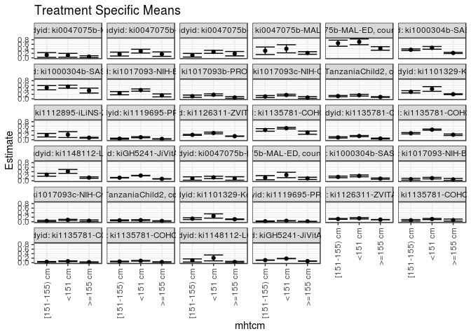

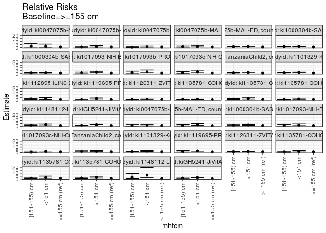

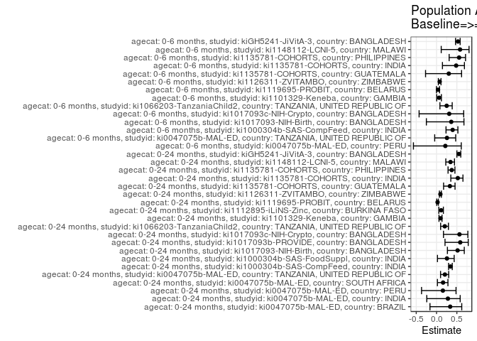

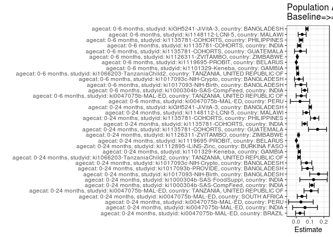

## Results Table

### Parameter: TSM

| agecat | studyid | country | intervention_level | baseline_level | estimate | ci_lower | ci_upper |
| --- | --- | --- | --- | --- | --- | --- | --- |
| 0-24 months | ki0047075b-MAL-ED | BRAZIL | >=155 cm | NA | 0.0538462 | 0.0149582 | 0.0927341 |
| 0-24 months | ki0047075b-MAL-ED | BRAZIL | <151 cm | NA | 0.1132075 | 0.0277128 | 0.1987022 |
| 0-24 months | ki0047075b-MAL-ED | BRAZIL | [151-155) cm | NA | 0.1282051 | 0.0230438 | 0.2333664 |
| 0-24 months | ki0047075b-MAL-ED | INDIA | >=155 cm | NA | 0.1636364 | 0.0656640 | 0.2616087 |
| 0-24 months | ki0047075b-MAL-ED | INDIA | <151 cm | NA | 0.2956522 | 0.2120760 | 0.3792283 |
| 0-24 months | ki0047075b-MAL-ED | INDIA | [151-155) cm | NA | 0.1666667 | 0.0804056 | 0.2529277 |
| 0-24 months | ki0047075b-MAL-ED | PERU | >=155 cm | NA | 0.1833333 | 0.0852567 | 0.2814100 |
| 0-24 months | ki0047075b-MAL-ED | PERU | <151 cm | NA | 0.2662722 | 0.1995170 | 0.3330274 |
| 0-24 months | ki0047075b-MAL-ED | PERU | [151-155) cm | NA | 0.1147541 | 0.0346326 | 0.1948756 |
| 0-24 months | ki0047075b-MAL-ED | SOUTH AFRICA | >=155 cm | NA | 0.2144269 | 0.1576297 | 0.2712240 |
| 0-24 months | ki0047075b-MAL-ED | SOUTH AFRICA | <151 cm | NA | 0.4008598 | 0.2208528 | 0.5808668 |
| 0-24 months | ki0047075b-MAL-ED | SOUTH AFRICA | [151-155) cm | NA | 0.3129289 | 0.1464151 | 0.4794427 |
| 0-24 months | ki0047075b-MAL-ED | TANZANIA, UNITED REPUBLIC OF | >=155 cm | NA | 0.4160599 | 0.3373202 | 0.4947996 |
| 0-24 months | ki0047075b-MAL-ED | TANZANIA, UNITED REPUBLIC OF | <151 cm | NA | 0.7087519 | 0.5813377 | 0.8361662 |
| 0-24 months | ki0047075b-MAL-ED | TANZANIA, UNITED REPUBLIC OF | [151-155) cm | NA | 0.6477343 | 0.5132649 | 0.7822036 |
| 0-24 months | ki1000304b-SAS-CompFeed | INDIA | >=155 cm | NA | 0.2166042 | 0.1892153 | 0.2439932 |
| 0-24 months | ki1000304b-SAS-CompFeed | INDIA | <151 cm | NA | 0.4413754 | 0.3807232 | 0.5020277 |
| 0-24 months | ki1000304b-SAS-CompFeed | INDIA | [151-155) cm | NA | 0.3580631 | 0.3229057 | 0.3932206 |
| 0-24 months | ki1000304b-SAS-FoodSuppl | INDIA | >=155 cm | NA | 0.3636200 | 0.2547878 | 0.4724522 |
| 0-24 months | ki1000304b-SAS-FoodSuppl | INDIA | <151 cm | NA | 0.5379749 | 0.4716569 | 0.6042928 |
| 0-24 months | ki1000304b-SAS-FoodSuppl | INDIA | [151-155) cm | NA | 0.4910123 | 0.3962186 | 0.5858059 |
| 0-24 months | ki1017093-NIH-Birth | BANGLADESH | >=155 cm | NA | 0.1501358 | 0.0837751 | 0.2164964 |
| 0-24 months | ki1017093-NIH-Birth | BANGLADESH | <151 cm | NA | 0.3873831 | 0.3371760 | 0.4375902 |
| 0-24 months | ki1017093-NIH-Birth | BANGLADESH | [151-155) cm | NA | 0.2476088 | 0.1766087 | 0.3186089 |
| 0-24 months | ki1017093b-PROVIDE | BANGLADESH | >=155 cm | NA | 0.0579710 | 0.0189525 | 0.0969895 |
| 0-24 months | ki1017093b-PROVIDE | BANGLADESH | <151 cm | NA | 0.1796247 | 0.1406387 | 0.2186106 |
| 0-24 months | ki1017093b-PROVIDE | BANGLADESH | [151-155) cm | NA | 0.1139241 | 0.0643462 | 0.1635019 |
| 0-24 months | ki1017093c-NIH-Crypto | BANGLADESH | >=155 cm | NA | 0.0571429 | 0.0186681 | 0.0956176 |
| 0-24 months | ki1017093c-NIH-Crypto | BANGLADESH | <151 cm | NA | 0.1678161 | 0.1326748 | 0.2029574 |
| 0-24 months | ki1017093c-NIH-Crypto | BANGLADESH | [151-155) cm | NA | 0.1000000 | 0.0561448 | 0.1438552 |

[output cut: 72 more lines]

### Parameter: E(Y)

| agecat | studyid | country | intervention_level | baseline_level | estimate | ci_lower | ci_upper |
| --- | --- | --- | --- | --- | --- | --- | --- |
| 0-24 months | ki0047075b-MAL-ED | BRAZIL | NA | NA | 0.0810811 | 0.0450937 | 0.1170685 |
| 0-24 months | ki0047075b-MAL-ED | INDIA | NA | NA | 0.2272727 | 0.1743641 | 0.2801813 |
| 0-24 months | ki0047075b-MAL-ED | PERU | NA | NA | 0.2172414 | 0.1696986 | 0.2647841 |
| 0-24 months | ki0047075b-MAL-ED | SOUTH AFRICA | NA | NA | 0.2555556 | 0.2034324 | 0.3076787 |
| 0-24 months | ki0047075b-MAL-ED | TANZANIA, UNITED REPUBLIC OF | NA | NA | 0.5234375 | 0.4621361 | 0.5847389 |
| 0-24 months | ki1000304b-SAS-CompFeed | INDIA | NA | NA | 0.3297797 | 0.2987556 | 0.3608038 |
| 0-24 months | ki1000304b-SAS-FoodSuppl | INDIA | NA | NA | 0.4889976 | 0.4404930 | 0.5375021 |
| 0-24 months | ki1017093-NIH-Birth | BANGLADESH | NA | NA | 0.3116057 | 0.2753823 | 0.3478292 |
| 0-24 months | ki1017093b-PROVIDE | BANGLADESH | NA | NA | 0.1390135 | 0.1127781 | 0.1652488 |
| 0-24 months | ki1017093c-NIH-Crypto | BANGLADESH | NA | NA | 0.1311258 | 0.1070332 | 0.1552185 |
| 0-24 months | ki1066203-TanzaniaChild2 | TANZANIA, UNITED REPUBLIC OF | NA | NA | 0.1000424 | 0.0879314 | 0.1121534 |
| 0-24 months | ki1101329-Keneba | GAMBIA | NA | NA | 0.2259259 | 0.2092953 | 0.2425566 |
| 0-24 months | ki1112895-iLiNS-Zinc | BURKINA FASO | NA | NA | 0.1032421 | 0.0833685 | 0.1231156 |
| 0-24 months | ki1119695-PROBIT | BELARUS | NA | NA | 0.0388088 | 0.0305671 | 0.0470504 |
| 0-24 months | ki1126311-ZVITAMBO | ZIMBABWE | NA | NA | 0.1757004 | 0.1681852 | 0.1832155 |
| 0-24 months | ki1135781-COHORTS | GUATEMALA | NA | NA | 0.4682663 | 0.4410469 | 0.4954857 |
| 0-24 months | ki1135781-COHORTS | INDIA | NA | NA | 0.1159496 | 0.1015724 | 0.1303268 |
| 0-24 months | ki1135781-COHORTS | PHILIPPINES | NA | NA | 0.3561151 | 0.3391405 | 0.3730897 |
| 0-24 months | ki1148112-LCNI-5 | MALAWI | NA | NA | 0.2114695 | 0.1837888 | 0.2391503 |
| 0-24 months | kiGH5241-JiVitA-3 | BANGLADESH | NA | NA | 0.1837058 | 0.1781339 | 0.1892777 |
| 0-6 months | ki0047075b-MAL-ED | PERU | NA | NA | 0.1275862 | 0.0891215 | 0.1660509 |
| 0-6 months | ki0047075b-MAL-ED | TANZANIA, UNITED REPUBLIC OF | NA | NA | 0.1406250 | 0.0979572 | 0.1832928 |
| 0-6 months | ki1000304b-SAS-CompFeed | INDIA | NA | NA | 0.1538462 | 0.1345929 | 0.1730994 |
| 0-6 months | ki1017093-NIH-Birth | BANGLADESH | NA | NA | 0.0937997 | 0.0709973 | 0.1166021 |
| 0-6 months | ki1017093c-NIH-Crypto | BANGLADESH | NA | NA | 0.0622517 | 0.0450059 | 0.0794974 |
| 0-6 months | ki1066203-TanzaniaChild2 | TANZANIA, UNITED REPUBLIC OF | NA | NA | 0.0432387 | 0.0350292 | 0.0514481 |
| 0-6 months | ki1101329-Keneba | GAMBIA | NA | NA | 0.1163114 | 0.1027818 | 0.1298410 |
| 0-6 months | ki1119695-PROBIT | BELARUS | NA | NA | 0.0128877 | 0.0095203 | 0.0162552 |
| 0-6 months | ki1126311-ZVITAMBO | ZIMBABWE | NA | NA | 0.1004065 | 0.0944680 | 0.1063450 |
| 0-6 months | ki1135781-COHORTS | GUATEMALA | NA | NA | 0.1018692 | 0.0837370 | 0.1200014 |
| 0-6 months | ki1135781-COHORTS | INDIA | NA | NA | 0.0443376 | 0.0350104 | 0.0536648 |
| 0-6 months | ki1135781-COHORTS | PHILIPPINES | NA | NA | 0.0624591 | 0.0538810 | 0.0710373 |
| 0-6 months | ki1148112-LCNI-5 | MALAWI | NA | NA | 0.0738007 | 0.0426155 | 0.1049860 |
| 0-6 months | kiGH5241-JiVitA-3 | BANGLADESH | NA | NA | 0.1465173 | 0.1415001 | 0.1515345 |

### Parameter: RR

| agecat | studyid | country | intervention_level | baseline_level | estimate | ci_lower | ci_upper |
| --- | --- | --- | --- | --- | --- | --- | --- |
| 0-24 months | ki0047075b-MAL-ED | BRAZIL | >=155 cm | >=155 cm | 1.0000000 | 1.0000000 | 1.000000 |
| 0-24 months | ki0047075b-MAL-ED | BRAZIL | <151 cm | >=155 cm | 2.1024259 | 0.7394462 | 5.977710 |
| 0-24 months | ki0047075b-MAL-ED | BRAZIL | [151-155) cm | >=155 cm | 2.3809524 | 0.7982073 | 7.102083 |
| 0-24 months | ki0047075b-MAL-ED | INDIA | >=155 cm | >=155 cm | 1.0000000 | 1.0000000 | 1.000000 |
| 0-24 months | ki0047075b-MAL-ED | INDIA | <151 cm | >=155 cm | 1.8067633 | 0.9318696 | 3.503058 |
| 0-24 months | ki0047075b-MAL-ED | INDIA | [151-155) cm | >=155 cm | 1.0185185 | 0.4615950 | 2.247381 |
| 0-24 months | ki0047075b-MAL-ED | PERU | >=155 cm | >=155 cm | 1.0000000 | 1.0000000 | 1.000000 |
| 0-24 months | ki0047075b-MAL-ED | PERU | <151 cm | >=155 cm | 1.4523938 | 0.8044622 | 2.622184 |
| 0-24 months | ki0047075b-MAL-ED | PERU | [151-155) cm | >=155 cm | 0.6259314 | 0.2597331 | 1.508434 |
| 0-24 months | ki0047075b-MAL-ED | SOUTH AFRICA | >=155 cm | >=155 cm | 1.0000000 | 1.0000000 | 1.000000 |
| 0-24 months | ki0047075b-MAL-ED | SOUTH AFRICA | <151 cm | >=155 cm | 1.8694477 | 1.1084107 | 3.153014 |
| 0-24 months | ki0047075b-MAL-ED | SOUTH AFRICA | [151-155) cm | >=155 cm | 1.4593738 | 0.8038839 | 2.649352 |
| 0-24 months | ki0047075b-MAL-ED | TANZANIA, UNITED REPUBLIC OF | >=155 cm | >=155 cm | 1.0000000 | 1.0000000 | 1.000000 |
| 0-24 months | ki0047075b-MAL-ED | TANZANIA, UNITED REPUBLIC OF | <151 cm | >=155 cm | 1.7034853 | 1.3117884 | 2.212142 |
| 0-24 months | ki0047075b-MAL-ED | TANZANIA, UNITED REPUBLIC OF | [151-155) cm | >=155 cm | 1.5568293 | 1.1751888 | 2.062407 |
| 0-24 months | ki1000304b-SAS-CompFeed | INDIA | >=155 cm | >=155 cm | 1.0000000 | 1.0000000 | 1.000000 |
| 0-24 months | ki1000304b-SAS-CompFeed | INDIA | <151 cm | >=155 cm | 2.0377047 | 1.8290231 | 2.270196 |
| 0-24 months | ki1000304b-SAS-CompFeed | INDIA | [151-155) cm | >=155 cm | 1.6530754 | 1.3642206 | 2.003091 |
| 0-24 months | ki1000304b-SAS-FoodSuppl | INDIA | >=155 cm | >=155 cm | 1.0000000 | 1.0000000 | 1.000000 |
| 0-24 months | ki1000304b-SAS-FoodSuppl | INDIA | <151 cm | >=155 cm | 1.4794973 | 1.0707021 | 2.044371 |
| 0-24 months | ki1000304b-SAS-FoodSuppl | INDIA | [151-155) cm | >=155 cm | 1.3503444 | 0.9457189 | 1.928089 |
| 0-24 months | ki1017093-NIH-Birth | BANGLADESH | >=155 cm | >=155 cm | 1.0000000 | 1.0000000 | 1.000000 |
| 0-24 months | ki1017093-NIH-Birth | BANGLADESH | <151 cm | >=155 cm | 2.5802181 | 1.6278068 | 4.089874 |
| 0-24 months | ki1017093-NIH-Birth | BANGLADESH | [151-155) cm | >=155 cm | 1.6492327 | 0.9731552 | 2.795000 |
| 0-24 months | ki1017093b-PROVIDE | BANGLADESH | >=155 cm | >=155 cm | 1.0000000 | 1.0000000 | 1.000000 |
| 0-24 months | ki1017093b-PROVIDE | BANGLADESH | <151 cm | >=155 cm | 3.0985255 | 1.5276458 | 6.284742 |
| 0-24 months | ki1017093b-PROVIDE | BANGLADESH | [151-155) cm | >=155 cm | 1.9651899 | 0.8816904 | 4.380190 |
| 0-24 months | ki1017093c-NIH-Crypto | BANGLADESH | >=155 cm | >=155 cm | 1.0000000 | 1.0000000 | 1.000000 |
| 0-24 months | ki1017093c-NIH-Crypto | BANGLADESH | <151 cm | >=155 cm | 2.9367816 | 1.4509154 | 5.944307 |
| 0-24 months | ki1017093c-NIH-Crypto | BANGLADESH | [151-155) cm | >=155 cm | 1.7500000 | 0.7835495 | 3.908496 |

[output cut: 72 more lines]

### Parameter: PAR

| agecat | studyid | country | intervention_level | baseline_level | estimate | ci_lower | ci_upper |
| --- | --- | --- | --- | --- | --- | --- | --- |
| 0-24 months | ki0047075b-MAL-ED | BRAZIL | >=155 cm | NA | 0.0272349 | -0.0049557 | 0.0594255 |
| 0-24 months | ki0047075b-MAL-ED | INDIA | >=155 cm | NA | 0.0636364 | -0.0260013 | 0.1532740 |
| 0-24 months | ki0047075b-MAL-ED | PERU | >=155 cm | NA | 0.0339080 | -0.0549686 | 0.1227847 |
| 0-24 months | ki0047075b-MAL-ED | SOUTH AFRICA | >=155 cm | NA | 0.0411287 | 0.0077348 | 0.0745226 |
| 0-24 months | ki0047075b-MAL-ED | TANZANIA, UNITED REPUBLIC OF | >=155 cm | NA | 0.1073776 | 0.0563526 | 0.1584026 |
| 0-24 months | ki1000304b-SAS-CompFeed | INDIA | >=155 cm | NA | 0.1131754 | 0.0966178 | 0.1297331 |
| 0-24 months | ki1000304b-SAS-FoodSuppl | INDIA | >=155 cm | NA | 0.1253775 | 0.0264387 | 0.2243164 |
| 0-24 months | ki1017093-NIH-Birth | BANGLADESH | >=155 cm | NA | 0.1614699 | 0.0972841 | 0.2256558 |
| 0-24 months | ki1017093b-PROVIDE | BANGLADESH | >=155 cm | NA | 0.0810424 | 0.0412600 | 0.1208249 |
| 0-24 months | ki1017093c-NIH-Crypto | BANGLADESH | >=155 cm | NA | 0.0739830 | 0.0351014 | 0.1128645 |
| 0-24 months | ki1066203-TanzaniaChild2 | TANZANIA, UNITED REPUBLIC OF | >=155 cm | NA | 0.0202455 | 0.0103958 | 0.0300951 |
| 0-24 months | ki1101329-Keneba | GAMBIA | >=155 cm | NA | 0.0221469 | 0.0136089 | 0.0306848 |
| 0-24 months | ki1112895-iLiNS-Zinc | BURKINA FASO | >=155 cm | NA | 0.0117382 | 0.0059591 | 0.0175172 |
| 0-24 months | ki1119695-PROBIT | BELARUS | >=155 cm | NA | 0.0009689 | 0.0001982 | 0.0017395 |
| 0-24 months | ki1126311-ZVITAMBO | ZIMBABWE | >=155 cm | NA | 0.0166487 | 0.0124401 | 0.0208573 |
| 0-24 months | ki1135781-COHORTS | GUATEMALA | >=155 cm | NA | 0.1540190 | 0.0885425 | 0.2194954 |
| 0-24 months | ki1135781-COHORTS | INDIA | >=155 cm | NA | 0.0607102 | 0.0422036 | 0.0792168 |
| 0-24 months | ki1135781-COHORTS | PHILIPPINES | >=155 cm | NA | 0.1330891 | 0.1029038 | 0.1632744 |
| 0-24 months | ki1148112-LCNI-5 | MALAWI | >=155 cm | NA | 0.0726093 | 0.0487646 | 0.0964539 |
| 0-24 months | kiGH5241-JiVitA-3 | BANGLADESH | >=155 cm | NA | 0.1012743 | 0.0920811 | 0.1104674 |
| 0-6 months | ki0047075b-MAL-ED | PERU | >=155 cm | NA | 0.0275862 | -0.0421924 | 0.0973648 |
| 0-6 months | ki0047075b-MAL-ED | TANZANIA, UNITED REPUBLIC OF | >=155 cm | NA | 0.0360498 | -0.0008223 | 0.0729220 |
| 0-6 months | ki1000304b-SAS-CompFeed | INDIA | >=155 cm | NA | 0.0610285 | 0.0390880 | 0.0829690 |
| 0-6 months | ki1017093-NIH-Birth | BANGLADESH | >=155 cm | NA | 0.0339706 | -0.0070364 | 0.0749777 |
| 0-6 months | ki1017093c-NIH-Crypto | BANGLADESH | >=155 cm | NA | 0.0193945 | -0.0123307 | 0.0511197 |
| 0-6 months | ki1066203-TanzaniaChild2 | TANZANIA, UNITED REPUBLIC OF | >=155 cm | NA | 0.0107865 | 0.0039851 | 0.0175880 |
| 0-6 months | ki1101329-Keneba | GAMBIA | >=155 cm | NA | 0.0073721 | 0.0006709 | 0.0140733 |
| 0-6 months | ki1119695-PROBIT | BELARUS | >=155 cm | NA | 0.0004738 | 0.0000136 | 0.0009340 |
| 0-6 months | ki1126311-ZVITAMBO | ZIMBABWE | >=155 cm | NA | 0.0078153 | 0.0045171 | 0.0111135 |
| 0-6 months | ki1135781-COHORTS | GUATEMALA | >=155 cm | NA | 0.0307607 | -0.0119474 | 0.0734688 |
| 0-6 months | ki1135781-COHORTS | INDIA | >=155 cm | NA | 0.0213920 | 0.0091019 | 0.0336820 |
| 0-6 months | ki1135781-COHORTS | PHILIPPINES | >=155 cm | NA | 0.0346785 | 0.0216411 | 0.0477158 |
| 0-6 months | ki1148112-LCNI-5 | MALAWI | >=155 cm | NA | 0.0427448 | 0.0138156 | 0.0716740 |
| 0-6 months | kiGH5241-JiVitA-3 | BANGLADESH | >=155 cm | NA | 0.0773008 | 0.0686883 | 0.0859132 |

### Parameter: PAF

| agecat | studyid | country | intervention_level | baseline_level | estimate | ci_lower | ci_upper |
| --- | --- | --- | --- | --- | --- | --- | --- |
| 0-24 months | ki0047075b-MAL-ED | BRAZIL | >=155 cm | NA | 0.3358974 | -0.1619039 | 0.6204228 |
| 0-24 months | ki0047075b-MAL-ED | INDIA | >=155 cm | NA | 0.2800000 | -0.2398021 | 0.5818688 |
| 0-24 months | ki0047075b-MAL-ED | PERU | >=155 cm | NA | 0.1560847 | -0.3691355 | 0.4798228 |
| 0-24 months | ki0047075b-MAL-ED | SOUTH AFRICA | >=155 cm | NA | 0.1609384 | 0.0214117 | 0.2805713 |
| 0-24 months | ki0047075b-MAL-ED | TANZANIA, UNITED REPUBLIC OF | >=155 cm | NA | 0.2051393 | 0.0988107 | 0.2989225 |
| 0-24 months | ki1000304b-SAS-CompFeed | INDIA | >=155 cm | NA | 0.3431850 | 0.2965718 | 0.3867093 |
| 0-24 months | ki1000304b-SAS-FoodSuppl | INDIA | >=155 cm | NA | 0.2563971 | 0.0228014 | 0.4341525 |
| 0-24 months | ki1017093-NIH-Birth | BANGLADESH | >=155 cm | NA | 0.5181867 | 0.2681276 | 0.6828081 |
| 0-24 months | ki1017093b-PROVIDE | BANGLADESH | >=155 cm | NA | 0.5829827 | 0.2084548 | 0.7802988 |
| 0-24 months | ki1017093c-NIH-Crypto | BANGLADESH | >=155 cm | NA | 0.5642136 | 0.1708072 | 0.7709703 |
| 0-24 months | ki1066203-TanzaniaChild2 | TANZANIA, UNITED REPUBLIC OF | >=155 cm | NA | 0.2023689 | 0.1004544 | 0.2927369 |
| 0-24 months | ki1101329-Keneba | GAMBIA | >=155 cm | NA | 0.0980272 | 0.0597766 | 0.1347216 |
| 0-24 months | ki1112895-iLiNS-Zinc | BURKINA FASO | >=155 cm | NA | 0.1136956 | 0.0558317 | 0.1680134 |
| 0-24 months | ki1119695-PROBIT | BELARUS | >=155 cm | NA | 0.0249653 | 0.0050789 | 0.0444542 |
| 0-24 months | ki1126311-ZVITAMBO | ZIMBABWE | >=155 cm | NA | 0.0947562 | 0.0707007 | 0.1181889 |
| 0-24 months | ki1135781-COHORTS | GUATEMALA | >=155 cm | NA | 0.3289132 | 0.1733425 | 0.4552067 |
| 0-24 months | ki1135781-COHORTS | INDIA | >=155 cm | NA | 0.5235908 | 0.3513310 | 0.6501055 |
| 0-24 months | ki1135781-COHORTS | PHILIPPINES | >=155 cm | NA | 0.3737250 | 0.2836085 | 0.4525055 |
| 0-24 months | ki1148112-LCNI-5 | MALAWI | >=155 cm | NA | 0.3433558 | 0.2274429 | 0.4418773 |
| 0-24 months | kiGH5241-JiVitA-3 | BANGLADESH | >=155 cm | NA | 0.5512851 | 0.5010372 | 0.5964728 |
| 0-6 months | ki0047075b-MAL-ED | PERU | >=155 cm | NA | 0.2162162 | -0.5688354 | 0.6084248 |
| 0-6 months | ki0047075b-MAL-ED | TANZANIA, UNITED REPUBLIC OF | >=155 cm | NA | 0.2563544 | -0.0454615 | 0.4710386 |
| 0-6 months | ki1000304b-SAS-CompFeed | INDIA | >=155 cm | NA | 0.3966854 | 0.2328908 | 0.5255062 |
| 0-6 months | ki1017093-NIH-Birth | BANGLADESH | >=155 cm | NA | 0.3621614 | -0.2505234 | 0.6746657 |
| 0-6 months | ki1017093c-NIH-Crypto | BANGLADESH | >=155 cm | NA | 0.3115502 | -0.4293673 | 0.6684105 |
| 0-6 months | ki1066203-TanzaniaChild2 | TANZANIA, UNITED REPUBLIC OF | >=155 cm | NA | 0.2494649 | 0.0833095 | 0.3855036 |
| 0-6 months | ki1101329-Keneba | GAMBIA | >=155 cm | NA | 0.0633825 | 0.0043182 | 0.1189431 |
| 0-6 months | ki1119695-PROBIT | BELARUS | >=155 cm | NA | 0.0367657 | -0.0019937 | 0.0740259 |
| 0-6 months | ki1126311-ZVITAMBO | ZIMBABWE | >=155 cm | NA | 0.0778364 | 0.0446629 | 0.1098580 |
| 0-6 months | ki1135781-COHORTS | GUATEMALA | >=155 cm | NA | 0.3019625 | -0.2706164 | 0.6165197 |
| 0-6 months | ki1135781-COHORTS | INDIA | >=155 cm | NA | 0.4824793 | 0.1453514 | 0.6866225 |
| 0-6 months | ki1135781-COHORTS | PHILIPPINES | >=155 cm | NA | 0.5552189 | 0.3101312 | 0.7132350 |
| 0-6 months | ki1148112-LCNI-5 | MALAWI | >=155 cm | NA | 0.5791925 | 0.1153040 | 0.7998421 |
| 0-6 months | kiGH5241-JiVitA-3 | BANGLADESH | >=155 cm | NA | 0.5275879 | 0.4674112 | 0.5809653 |